## Importing The Libraries

```python
import numpy as np
import pandas as pd
import matplotlib.pyplot as plt
import seaborn as sns
import warnings
warnings.filterwarnings("ignore")
```

# Reading the dataset

```python
df=pd.read_csv('aerofit_treadmill.csv')
```

```python
df.head()
```

|  | Product | Age | Gender | Education | MaritalStatus | Usage | Fitness | Income | Miles |
| --- | --- | --- | --- | --- | --- | --- | --- | --- | --- |
| 0 | KP281 | 18 | Male | 14 | Single | 3 | 4 | 29562 | 112 |
| 1 | KP281 | 19 | Male | 15 | Single | 2 | 3 | 31836 | 75 |
| 2 | KP281 | 19 | Female | 14 | Partnered | 4 | 3 | 30699 | 66 |
| 3 | KP281 | 19 | Male | 12 | Single | 3 | 3 | 32973 | 85 |
| 4 | KP281 | 20 | Male | 13 | Partnered | 4 | 2 | 35247 | 47 |

# Data types of the Columns

```python
df.info()
```

```
<class 'pandas.core.frame.DataFrame'>
RangeIndex: 180 entries, 0 to 179
Data columns (total 9 columns):
 #   Column         Non-Null Count  Dtype
---  ------         --------------  -----
 0   Product        180 non-null    object
 1   Age            180 non-null    int64
 2   Gender         180 non-null    object
 3   Education      180 non-null    int64
 4   MaritalStatus  180 non-null    object
 5   Usage          180 non-null    int64
 6   Fitness        180 non-null    int64
 7   Income         180 non-null    int64
 8   Miles          180 non-null    int64
dtypes: int64(6), object(3)
memory usage: 12.8+ KB
```

# Rows and columns of the data

```python
df.shape
```

```
(180, 9)
```

So our data has 180 rows and 9 columns.

```python
df.columns
```

```
Index(['Product', 'Age', 'Gender', 'Education', 'MaritalStatus', 'Usage',
       'Fitness', 'Income', 'Miles'],
      dtype='object')
```

```python
df.describe()
```

|  | Age | Education | Usage | Fitness | Income | Miles |
| --- | --- | --- | --- | --- | --- | --- |
| count | 180.000000 | 180.000000 | 180.000000 | 180.000000 | 180.000000 | 180.000000 |
| mean | 28.788889 | 15.572222 | 3.455556 | 3.311111 | 53719.577778 | 103.194444 |
| std | 6.943498 | 1.617055 | 1.084797 | 0.958869 | 16506.684226 | 51.863605 |
| min | 18.000000 | 12.000000 | 2.000000 | 1.000000 | 29562.000000 | 21.000000 |
| 25% | 24.000000 | 14.000000 | 3.000000 | 3.000000 | 44058.750000 | 66.000000 |
| 50% | 26.000000 | 16.000000 | 3.000000 | 3.000000 | 50596.500000 | 94.000000 |
| 75% | 33.000000 | 16.000000 | 4.000000 | 4.000000 | 58668.000000 | 114.750000 |
| max | 50.000000 | 21.000000 | 7.000000 | 5.000000 | 104581.000000 | 360.000000 |

```python
df['Product'].unique()
```

```
array(['KP281', 'KP481', 'KP781'], dtype=object)
```

## Count of Categorical Variables

```python
df['Product'].value_counts()
```

```
KP281    80
KP481    60
KP781    40
Name: Product, dtype: int64
```

- There are basically 3 unique products / treadmill for aerofit.
- KP281 is the most popular product for Aerofit due to it's lower price . Another important feature is that it can be used by beginners.

```python
df['Fitness'].value_counts()
```

```
3    97
5    31
2    26
4    24
1     2
Name: Fitness, dtype: int64
```

```python
df['MaritalStatus'].value_counts()
```

```
Partnered    107
Single        73
Name: MaritalStatus, dtype: int64
```

```python
df['Usage'].value_counts()
```

```
3    69
4    52
2    33
5    17
6     7
7     2
Name: Usage, dtype: int64
```

# Checking for missing values

```python
df.isna().sum()
```

```
Product          0
Age              0
Gender           0
Education        0
MaritalStatus    0
Usage            0
Fitness          0
Income           0
Miles            0
dtype: int64
```

# Insight: There is no missing value present in the dataset.

## Univariate Analysis of Continuous Variables

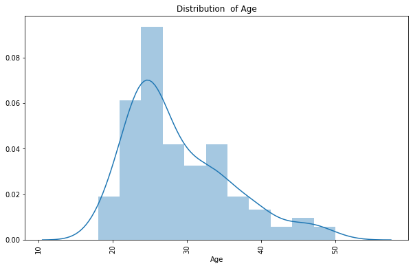

```python
# Visualize distributions for Age variable
plt.figure(figsize=(10, 6))
sns.distplot(df['Age'])
plt.title('Distribution  of Age')
plt.xlabel('Age')

plt.xticks(rotation=90)
plt.show()
```

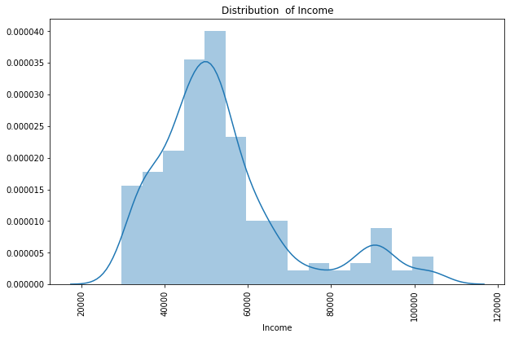

```python
# Visualize distributions for Age variable
plt.figure(figsize=(10, 6))
sns.distplot(df['Income'])
plt.title('Distribution  of Income')
plt.xlabel('Income')
plt.xticks(rotation=90)
plt.show()
```

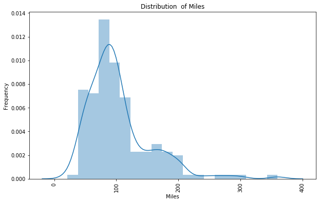

```python
# Visualize distributions for Age variable
plt.figure(figsize=(10, 6))
sns.distplot(df['Miles'])
plt.title('Distribution  of Miles')
plt.xlabel('Miles')
plt.ylabel('Frequency')
plt.xticks(rotation=90)
plt.show()
```

# Checking the outliers of continuous Variables.

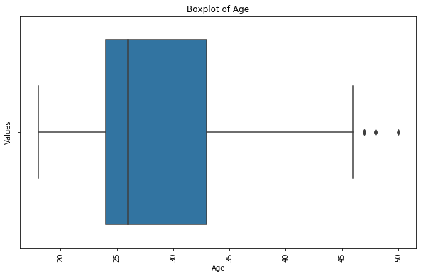

```python
# Visualize boxplots for Age variable
plt.figure(figsize=(10, 6))
sns.boxplot(df['Age'])
plt.title('Boxplot of Age')
plt.xlabel('Age')
plt.ylabel('Values')
plt.xticks(rotation=90)
plt.show()
```

1. From the boxplot we can see there are 3 outliers present in the dataset.
2. The median age is 26 & most of the cuistomers belong in the range of 24-33 years.

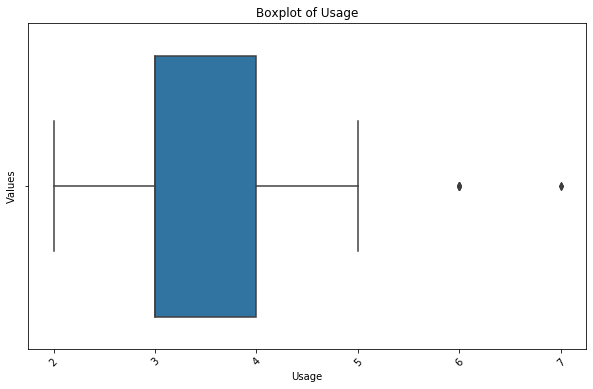

```python
# Visualize boxplots for Usage variable
plt.figure(figsize=(10, 6))
sns.boxplot(df['Usage'])
plt.title('Boxplot of Usage')
plt.xlabel('Usage')
plt.ylabel('Values')
plt.xticks(rotation=45)
plt.show()
```

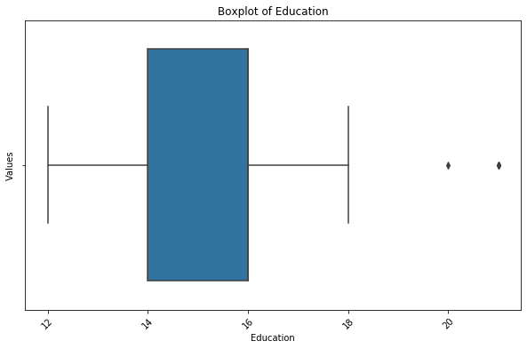

```python
# Visualize boxplots for Education variable
plt.figure(figsize=(10, 6))
sns.boxplot(df['Education'])
plt.title('Boxplot of Education')
plt.xlabel('Education')
plt.ylabel('Values')
plt.xticks(rotation=45)
plt.show()
```

1. From the boxplot we can see there are 2 outliers present in the Education variable.
2. The median education is of 16 Years & most of the customers recieved education in the range of 14-16 years.

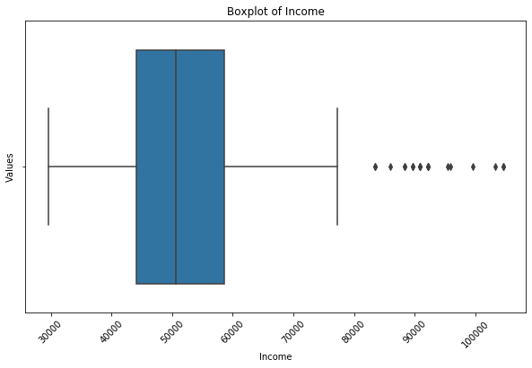

```python
# Visualize boxplots for Income variable
plt.figure(figsize=(10, 6))
sns.boxplot(df['Income'])
plt.title('Boxplot of Income')
plt.xlabel('Income')
plt.ylabel('Values')
plt.xticks(rotation=45)
plt.show()
```

1. From the boxplot we can see there are many outliers present in the Income Variable. This indicates that aerofit caters to some rich customers who have annual income of more than $80000.
2. The median income of customers is 51k & most of the cuistomers belong in the range of 44k-59k per year.

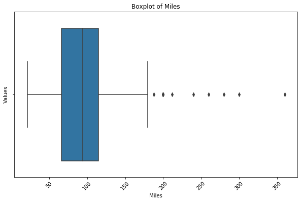

```python
# Visualize boxplots for Miles variable
plt.figure(figsize=(10, 6))
sns.boxplot(df['Miles'])
plt.title('Boxplot of Miles')
plt.xlabel('Miles')
plt.ylabel('Values')
plt.xticks(rotation=45)
plt.show()
```

1. From the boxplot we can see there are many outliers present in the Miles Variable. This indicates that aerofit caters to some health concious/athlete customers who run more than 180 miles per week.
2. The median miles per week of customers is 94 miles & most of the cuistomers belong in the range of 66-115 miles per week.

# Clipping the continuous variables between 5 percentile and 95 percentile wherever outliers are present

```python
# Clipping the values for education column
fifth_percentile=np.percentile(df['Education'],5)
max_percentile=np.percentile(df['Education'],95)
df['Education_clipped']=np.clip(df['Education'],fifth_percentile,max_percentile)
df
```

|  | Product | Age | Gender | Education | MaritalStatus | Usage | Fitness | Income | Miles | Education_clipped |
| --- | --- | --- | --- | --- | --- | --- | --- | --- | --- | --- |
| 0 | KP281 | 18 | Male | 14 | Single | 3 | 4 | 29562 | 112 | 14 |
| 1 | KP281 | 19 | Male | 15 | Single | 2 | 3 | 31836 | 75 | 15 |
| 2 | KP281 | 19 | Female | 14 | Partnered | 4 | 3 | 30699 | 66 | 14 |
| 3 | KP281 | 19 | Male | 12 | Single | 3 | 3 | 32973 | 85 | 14 |
| 4 | KP281 | 20 | Male | 13 | Partnered | 4 | 2 | 35247 | 47 | 14 |
| ... | ... | ... | ... | ... | ... | ... | ... | ... | ... | ... |
| 175 | KP781 | 40 | Male | 21 | Single | 6 | 5 | 83416 | 200 | 18 |
| 176 | KP781 | 42 | Male | 18 | Single | 5 | 4 | 89641 | 200 | 18 |
| 177 | KP781 | 45 | Male | 16 | Single | 5 | 5 | 90886 | 160 | 16 |
| 178 | KP781 | 47 | Male | 18 | Partnered | 4 | 5 | 104581 | 120 | 18 |
| 179 | KP781 | 48 | Male | 18 | Partnered | 4 | 5 | 95508 | 180 | 18 |

180 rows × 10 columns

```python
# Clipping the values for age column
fifth_percentile=np.percentile(df['Age'],5)
max_percentile=np.percentile(df['Age'],95)
df['Age_clipped']=np.clip(df['Age'],fifth_percentile,max_percentile)
df
# df['Age_clipped']=df['Age'].apply(lambda x: min(max_percentile,x))
```

|  | Product | Age | Gender | Education | MaritalStatus | Usage | Fitness | Income | Miles | Education_clipped | Age_clipped |
| --- | --- | --- | --- | --- | --- | --- | --- | --- | --- | --- | --- |
| 0 | KP281 | 18 | Male | 14 | Single | 3 | 4 | 29562 | 112 | 14 | 20.00 |
| 1 | KP281 | 19 | Male | 15 | Single | 2 | 3 | 31836 | 75 | 15 | 20.00 |
| 2 | KP281 | 19 | Female | 14 | Partnered | 4 | 3 | 30699 | 66 | 14 | 20.00 |
| 3 | KP281 | 19 | Male | 12 | Single | 3 | 3 | 32973 | 85 | 14 | 20.00 |
| 4 | KP281 | 20 | Male | 13 | Partnered | 4 | 2 | 35247 | 47 | 14 | 20.00 |
| ... | ... | ... | ... | ... | ... | ... | ... | ... | ... | ... | ... |
| 175 | KP781 | 40 | Male | 21 | Single | 6 | 5 | 83416 | 200 | 18 | 40.00 |
| 176 | KP781 | 42 | Male | 18 | Single | 5 | 4 | 89641 | 200 | 18 | 42.00 |
| 177 | KP781 | 45 | Male | 16 | Single | 5 | 5 | 90886 | 160 | 16 | 43.05 |
| 178 | KP781 | 47 | Male | 18 | Partnered | 4 | 5 | 104581 | 120 | 18 | 43.05 |
| 179 | KP781 | 48 | Male | 18 | Partnered | 4 | 5 | 95508 | 180 | 18 | 43.05 |

180 rows × 11 columns

```python
# Clipping the values for Income column
fifth_percentile=np.percentile(df['Income'],5)
max_percentile=np.percentile(df['Income'],95)
df['Income_clipped']=np.clip(df['Income'],fifth_percentile,max_percentile)
df
```

|  | Product | Age | Gender | Education | MaritalStatus | Usage | Fitness | Income | Miles | Education_clipped | Age_clipped | Income_clipped |
| --- | --- | --- | --- | --- | --- | --- | --- | --- | --- | --- | --- | --- |
| 0 | KP281 | 18 | Male | 14 | Single | 3 | 4 | 29562 | 112 | 14 | 20.00 | 34053.15 |
| 1 | KP281 | 19 | Male | 15 | Single | 2 | 3 | 31836 | 75 | 15 | 20.00 | 34053.15 |
| 2 | KP281 | 19 | Female | 14 | Partnered | 4 | 3 | 30699 | 66 | 14 | 20.00 | 34053.15 |
| 3 | KP281 | 19 | Male | 12 | Single | 3 | 3 | 32973 | 85 | 14 | 20.00 | 34053.15 |
| 4 | KP281 | 20 | Male | 13 | Partnered | 4 | 2 | 35247 | 47 | 14 | 20.00 | 35247.00 |
| ... | ... | ... | ... | ... | ... | ... | ... | ... | ... | ... | ... | ... |
| 175 | KP781 | 40 | Male | 21 | Single | 6 | 5 | 83416 | 200 | 18 | 40.00 | 83416.00 |
| 176 | KP781 | 42 | Male | 18 | Single | 5 | 4 | 89641 | 200 | 18 | 42.00 | 89641.00 |
| 177 | KP781 | 45 | Male | 16 | Single | 5 | 5 | 90886 | 160 | 16 | 43.05 | 90886.00 |
| 178 | KP781 | 47 | Male | 18 | Partnered | 4 | 5 | 104581 | 120 | 18 | 43.05 | 90948.25 |
| 179 | KP781 | 48 | Male | 18 | Partnered | 4 | 5 | 95508 | 180 | 18 | 43.05 | 90948.25 |

180 rows × 12 columns

```python
# Clipping the values for Miles column
fifth_percentile=np.percentile(df['Miles'],5)
max_percentile=np.percentile(df['Miles'],95)
df['Miles_clipped']=np.clip(df['Miles'],fifth_percentile,max_percentile)
df
```

|  | Product | Age | Gender | Education | MaritalStatus | Usage | Fitness | Income | Miles | Education_clipped | Age_clipped | Income_clipped | Miles_clipped |
| --- | --- | --- | --- | --- | --- | --- | --- | --- | --- | --- | --- | --- | --- |
| 0 | KP281 | 18 | Male | 14 | Single | 3 | 4 | 29562 | 112 | 14 | 20.00 | 34053.15 | 112 |
| 1 | KP281 | 19 | Male | 15 | Single | 2 | 3 | 31836 | 75 | 15 | 20.00 | 34053.15 | 75 |
| 2 | KP281 | 19 | Female | 14 | Partnered | 4 | 3 | 30699 | 66 | 14 | 20.00 | 34053.15 | 66 |
| 3 | KP281 | 19 | Male | 12 | Single | 3 | 3 | 32973 | 85 | 14 | 20.00 | 34053.15 | 85 |
| 4 | KP281 | 20 | Male | 13 | Partnered | 4 | 2 | 35247 | 47 | 14 | 20.00 | 35247.00 | 47 |
| ... | ... | ... | ... | ... | ... | ... | ... | ... | ... | ... | ... | ... | ... |
| 175 | KP781 | 40 | Male | 21 | Single | 6 | 5 | 83416 | 200 | 18 | 40.00 | 83416.00 | 200 |
| 176 | KP781 | 42 | Male | 18 | Single | 5 | 4 | 89641 | 200 | 18 | 42.00 | 89641.00 | 200 |
| 177 | KP781 | 45 | Male | 16 | Single | 5 | 5 | 90886 | 160 | 16 | 43.05 | 90886.00 | 160 |
| 178 | KP781 | 47 | Male | 18 | Partnered | 4 | 5 | 104581 | 120 | 18 | 43.05 | 90948.25 | 120 |
| 179 | KP781 | 48 | Male | 18 | Partnered | 4 | 5 | 95508 | 180 | 18 | 43.05 | 90948.25 | 180 |

180 rows × 13 columns

## Relationship between the categorical variables and the output variable in the data

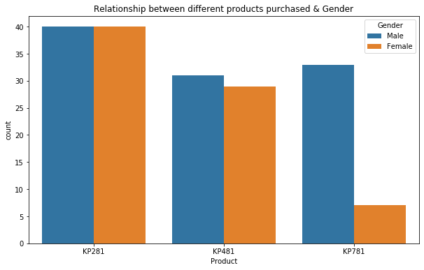

```python
plt.figure(figsize=(10,6))
sns.countplot(data=df,x='Product',hue='Gender')
plt.title('Relationship between different products purchased & Gender')
plt.show()
```